# Replication Code: Discounting of Probabilistic Food Reinforcement by Pigeons

Author

Haoran (Matt) Wan

Published

October 31, 2025

## Introduction

This document contains the complete R code to replicate the analyses from the publication:

> Oliveira, L., Green, L., Myerson, J., & Wan, H. (2025). Discounting of probabilistic food reinforcement by pigeons. *Journal of the Experimental Analysis of Behavior, 124*(1). https://doi.org/10.1002/jeab.70042

The analysis uses Bayesian nonlinear multilevel models via `brms` to fit a hyperboloid discounting function to pigeons’ choices. **Experiment 1** examines choices between a certain and a probabilistic reward.**Experiment 2** extends this to choices between two probabilistic rewards.

The data for this study are publicly available on the Open Science Framework at: https://osf.io/scwg3/.

This Quarto document is structured as follows:

1. **Setup**: Loads all required packages, sets global options, defines custom functions, and processes the raw data.
2. **Experiment 1**: Fits and visualizes the models for choices between certain and probabilistic rewards.
3. **Experiment 2**: Fits and visualizes the generalized models for choices between two probabilistic rewards.

```r
# This chunk sets up the global environment, loads all required packages,
# and processes the raw data into analysis-ready dataframes.

# --- SETUP: PACKAGES, OPTIONS, AND FUNCTIONS ---

# --- 1. LOAD PACKAGES ---
library(minpack.lm) # For non-linear least squares (used in paper, though brms is primary)
library(tidybayes)    # For processing and visualizing Bayesian model posteriors
library(bayestestR)   # For calculating probability of direction (pd)
library(modelr)       # For creating model-based data grids
library(multcomp)     # For post-hoc comparisons
library(glmmTMB)      # For frequentist mixed-effects models (e.g., AUC analysis)
library(broom)        # For tidying model outputs
library(lemon)        # For enhancing ggplot2 facets
library(brms)         # For Bayesian multilevel modeling
library(rstan)        # For Bayesian multilevel modeling
library(scales)       # For scaling plot axes
library(ggpubr)       # For arranging ggplot objects
library(here)         # For reproducible file paths
library(readr)        # For reading CSV files
library(tidyverse)    # For data manipulation and visualization (ggplot2, dplyr, etc.)

# --- 2. CUSTOM FUNCTIONS & THEME ---

#' Custom ggplot2 Theme for Publication-Ready Plots
#' @description A standardized theme for consistent plot aesthetics.
mattheme <- theme(
  text = element_text(size = 14, family = "Arial", color = "black", face = "bold"),
  axis.text.y = element_text(colour = "black", size = 10, face = "bold"),
  axis.text.x = element_text(colour = "black", size = 10, face = "bold", angle = 0),
  axis.title.x = element_text(margin = margin(7, 0, 0, 0), size = 14),
  axis.title.y = element_text(margin = margin(0, 7, 0, 0), size = 14),
  axis.line = element_line(color = "black", size = 1),
  plot.title = element_text(size = 16, face = "bold", hjust = 0.5),
  panel.background = element_rect(fill = "white"),
  panel.grid = element_blank(),
  strip.background = element_blank(),
  strip.text = element_text(size=14),
  legend.key = element_blank()
)

#' Area Under the Curve (AuC) Calculation
#' @description Calculates the area under the curve using the trapezoidal rule.
#' @param x A numeric vector of x-coordinates (e.g., normalized odds against).
#' @param y A numeric vector of y-coordinates (e.g., relative subjective values).
#' @return The calculated area as a single numeric value.
calculate_AuC <- function(x, y) {
  sum(diff(x) * (y[-1] + y[-length(y)])) / 2
}

# --- 3. LOAD RAW DATA ---
# Load the data files from the OSF repository folder.
raw_data_exp1 <- read_csv("PigeonPD_Exp1.csv")
raw_data_exp2 <- read_csv("PigeonPD_Exp2.csv")

# --- 4. PROCESS EXPERIMENT 1 DATA ---
# Transform raw data into an analysis-ready format.
processed_data_exp1 <- raw_data_exp1 |>
  mutate(
    Experiment = 1,
    # Flag replication conditions
    Rep = as.numeric(str_detect(Probability, "R")),
    # Convert probability to numeric (0-1)
    Prob_Lg = as.numeric(str_remove(Probability, "R")) / 100,
    # Calculate Odds Against (OAs)
    OAs = (1 - Prob_Lg) / Prob_Lg,
    # Calculate Relative Subjective Value (RSV)
    RSV = SV / Amount,
    # Set Multiplier to 1.0 (for consistency with Exp 2)
    Multiplier = 1.0,
    # Set Odds Against for the Smaller (certain) option to 0
    OAs_Sm = 0
  ) |>
  # Select and rename columns for clarity
  select(Subject, Experiment, Multiplier, Amount, Rep, OAs, RSV, OAs_Sm, Prob_Lg)

# --- 5. PROCESS EXPERIMENT 2 DATA ---
processed_data_exp2 <- raw_data_exp2 |>
  mutate(
    Experiment = 2,
    # Flag replication conditions
    Rep = as.numeric(str_detect(Multiplier, "R")),
    # Convert multiplier to numeric
    Multiplier = as.numeric(str_remove(Multiplier, "R")),
    # Convert probabilities to numeric (0-1)
    Prob_Lg = Probability_Lg / 100,
    Prob_Sm = Probability_Sm / 100,
    # Calculate Odds Against (OAs) for both options
    OAs = (1 - Prob_Lg) / Prob_Lg,
    OAs_Sm = (1 - Prob_Sm) / Prob_Sm,
    # Calculate Relative Subjective Value (RSV)
    RSV = SV / Amount
  ) |>
  # Select and rename columns for clarity
  select(Subject, Experiment, Multiplier, Amount, Rep, OAs, RSV, OAs_Sm, Prob_Lg)

# --- 6. COMBINE DATA & CREATE MEAN SUBJECT ---
# Bind the two experiments into a single dataframe
combined_data <- bind_rows(processed_data_exp1, processed_data_exp2)

# Calculate the mean RSV across all subjects for plotting
mean_data <- combined_data |>
  filter(Rep == 0) |> # Exclude replication data from mean calculation
  group_by(Experiment, Amount, Multiplier, OAs, Prob_Lg, OAs_Sm) |>
  summarise(RSV = mean(RSV), .groups = 'drop') |>
  mutate(Subject = "Mean", Rep = 0) # Add a "Mean" subject

# --- 7. CREATE FINAL ANALYSIS DATAFRAMES ---

# Create a dataframe for plotting (collapses across OAs)
plot_data_mean <- combined_data |>
  group_by(Subject, Experiment, Multiplier, Amount, Prob_Lg, Rep) |>
  summarise_all(mean) |> # Get mean RSV for each condition
  select(-OAs_Sm) |>
  ungroup() |>
  mutate(
    # Convert Amount to a factor for plotting
    Amount = factor(Amount, levels = c(32, 16), labels = c("32 Pellets", "16 Pellets"))
  )

# Create a dataframe for AuC analysis
auc_data <- combined_data |>
  filter(Rep == 0) |> # Exclude replication data
  group_by(Subject, Experiment, Multiplier, Amount) |>
  arrange(OAs, .by_group = TRUE) |> # Ensure OAs are in ascending order
  # Calculate AuC, normalizing OAs to a 0-1 scale
  summarise(AuC = calculate_AuC(OAs / max(OAs), RSV), .groups = 'drop')
```

## Experiment 1: Certain vs. Probabilistic Rewards

In Experiment 1, pigeons chose between a smaller, certain reinforcer and a larger, probabilistic reinforcer. The following section fits the hyperboloid discounting model (Equation 1 from the paper) to the data for each amount (16 and 32 pellets).

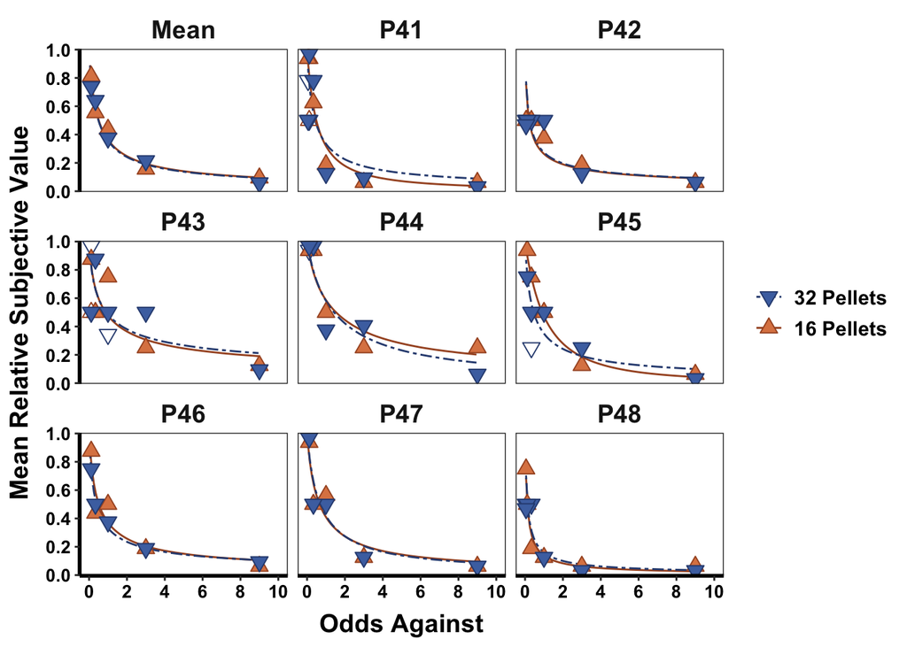

```r
# --- 1. Define Bayesian Nonlinear Model (Exp 1) ---
# We fit the hyperboloid model: RSV = 1 / (1 + b * OAs)^s
# We use a logit-transformed formula because the 'beta_family()' in brms
# models the mean 'mu' on the logit scale: logit(mu) = eta.
# Therefore, eta = logit(1 / (1 + b * OAs)^s)
exp1_model_formula <- bf(
  RSV ~ log((1 / (1 + b*OAs)^s) / (1 - (1 / (1 + b*OAs)^s))),
  # 'b' (rate) and 's' (scaling) are non-linear parameters,
  # estimated separately for each Subject.
  b + s ~ 0 + Subject,
  # 'phi' (precision) is also estimated for each Subject.
  phi ~ 0 + Subject,
  nl = TRUE
)

# --- 2. Set Priors ---
# Priors are set based on the paper: normal(1, 10) for b and s.
# We use weakly informative priors to help stabilize estimates.
model_priors <- c(
  prior(normal(1, 10), class = b, nlpar = b, lb = 0), # 'b' (rate)
  prior(normal(1, 10), class = b, nlpar = s, lb = 0), # 's' (scaling)
  prior(normal(0, 100^100), class = b, dpar = phi)    # 'phi' (precision)
)

# --- 3. Fit Model for 16-Pellet Amount ---
model_exp1_16p <- brm(
  formula = exp1_model_formula,
  data = filter(combined_data, Experiment == 1 & Rep == 0 & Amount == 16),
  family = beta_family(),
  prior = model_priors,
  iter = 4000, warmup = 2000, chains = 4, cores = 4, refresh = 0,
  backend = "cmdstanr",
  control = list(adapt_delta = 0.95, max_treedepth = 10),
  file = "rds/bf_mod1.rds" # Cache model fit
)

# --- 4. Fit Model for 32-Pellet Amount ---
model_exp1_32p <- brm(
  formula = exp1_model_formula,
  data = filter(combined_data, Experiment == 1 & Rep == 0 & Amount == 32),
  family = beta_family(),
  prior = model_priors,
  iter = 4000, warmup = 2000, chains = 4, cores = 4, refresh = 0,
  backend = "cmdstanr",
  control = list(adapt_delta = 0.95, max_treedepth = 10),
  file = "rds/bf_mod2.rds" # Cache model fit
)

# --- 5. Generate Predictions from Posterior ---
# Create a grid of OAs values for each subject to draw smooth curves
pred_grid_exp1_16p <- tidyr::expand(
  ungroup(filter(combined_data, Experiment == 1 & Rep == 0 & Amount == 16)),
  Subject = unique(Subject),
  OAs = seq(min(OAs), max(OAs), .1)
)
pred_grid_exp1_32p <- tidyr::expand(
  ungroup(filter(combined_data, Experiment == 1 & Rep == 0 & Amount == 32)),
  Subject = unique(Subject),
  OAs = seq(min(OAs), max(OAs), .1)
)

# Get posterior predictions and summarize using the median
pred_curves_exp1 <- add_epred_draws(model_exp1_16p, newdata = pred_grid_exp1_16p) |>
  group_by(Subject, OAs) |>
  summarize(.epred = median(.epred), Amount = "16 Pellets", .groups = 'drop') |>
  # Bind with predictions from the 32-pellet model
  rbind(
    add_epred_draws(model_exp1_32p, newdata = pred_grid_exp1_32p) |>
      group_by(Subject, OAs) |>
      summarize(.epred = median(.epred), Amount = "32 Pellets", .groups = 'drop')
  )

# --- 6. Plot Data and Model Fits (Replicates Figure 1) ---
ggplot(filter(plot_data_mean, Experiment == 1 & Rep == 0),
       aes(OAs, RSV, shape = Amount, group = Amount, linetype = Amount, fill = Amount, color = Amount)) +
  # Plot the smooth model-fit curves
  geom_line(data = pred_curves_exp1, aes(x = OAs, y = .epred, group = Amount, linetype = Amount)) +
  # Plot the replication data (open symbols)
  geom_point(data = filter(plot_data_mean, Experiment == 1 & Rep == 1), size = 3, fill = NA, show.legend = FALSE) +
  # Plot the original data (filled symbols)
  geom_point(size = 3) +
  scale_y_continuous(limits = c(-.005, 1.005), breaks = seq(0, 1, by = 0.2), expand = c(0,0)) +
  scale_x_continuous(limits = c(0, 10), breaks = seq(0, 10, by = 2)) +
  scale_shape_manual(name = NULL, values = c("32 Pellets" = 25, "16 Pellets" = 24)) +
  scale_linetype_manual(name = NULL, values = c("32 Pellets" = "twodash", "16 Pellets" = "solid")) +
  scale_fill_manual(name = NULL, values = c("32 Pellets" = "#4C72B0", "16 Pellets" = "#DD8452")) +
  scale_color_manual(name = NULL, values = c("32 Pellets" = "#2E4A7F", "16 Pellets" = "#A65329")) +
  labs(x = "Odds Against", y = "Mean Relative Subjective Value", shape = NULL, fill = NULL) +
  facet_wrap(~Subject, ncol = 3) +
  theme_bw() + mattheme
```

The table below replicates the key findings from Table 1 in the paper, showing the AuC, Bayesian $R^2$, and posterior estimates for the discounting parameters *b* and *s*.

The plot replicates Figure 2, showing the difference in AuC between the 16- and 32-pellet conditions for each pigeon.

```r
# --- 1. Calculate Bayesian R-squared ---
# This approach calculates the variance in the median posterior predictions
# relative to the variance in the observed data.
r2_data_exp1 <- bind_rows(
    # Get median posterior prediction for each data point
    cbind(filter(combined_data, Experiment == 1 & Rep == 0 & Amount == 16),
          as.data.frame(t(posterior_epred(model_exp1_16p)))),
    cbind(filter(combined_data, Experiment == 1 & Rep == 0 & Amount == 32),
          as.data.frame(t(posterior_epred(model_exp1_32p))))
  ) |>
  # Convert from wide (simulations) to long format
  pivot_longer(cols = starts_with("V"), names_to = "Sim", values_to = ".epred") |>
  # Find the median prediction for each observation
  group_by(Subject, Amount, OAs, RSV) |>
  summarize(.epred = median(.epred), .groups = 'drop') |>
  mutate(residual = RSV - .epred) |>
  # Calculate sum of squares
  group_by(Subject, Amount) |>
  mutate(residual2 = residual^2, tot = (RSV - mean(RSV))^2) |>
  summarise(ss_res = sum(residual2), ss_tot = sum(tot), .groups = 'drop') |>
  # Calculate R-squared
  mutate(R2 = 1 - (ss_res / ss_tot)) |>
  select(Subject, Amount, R2)

# --- 2. Extract Parameter Estimates ---
# Gather posterior draws for 'b' and 's' parameters from both models
params_data_exp1 <- gather_draws(model_exp1_16p, `b_.*`, regex=TRUE)[,-c(1:3)] |> mutate(Amount = 16) |>
  rbind(gather_draws(model_exp1_32p, `b_.*`, regex=TRUE)[,-c(1:3)] |> mutate(Amount = 32)) |>
  # Clean variable names
  separate(col = .variable, into = c("Parameter", "Subject"), sep = "_Subject") |>
  mutate(Parameter = str_remove(Parameter, "b_")) |>
  filter(Parameter != "phi") |> # Exclude precision parameter
  # Calculate probability of direction (pd) relative to 1.0
  group_by(Subject, Amount, Parameter) |>
  mutate(pd = ecdf(.value)(1), pd = ifelse(pd>=.5, pd, 1-pd)) |>
  # Summarize posteriors (median, sd)
  group_by(Parameter,Subject,Amount,pd) |>
  summarise(se=sd(.value), .value=median(.value), .groups = 'drop') |>
  mutate(pd = ifelse(Parameter=="b" & .value < 1 & pd > .5, 1 - pd,
                     ifelse(Parameter=="s" & .value > 1 & pd > .5, 1 - pd, pd))) |>
  # Format for table
  mutate(across(c(.value, se, pd), ~sprintf("%.3f", round(.,3)))) |>
  ungroup() |>
  mutate(se = paste0("(", se, ")")) |>
  rename("Estimate" = ".value", "SE" = "se") |>
  unite("Estimate (SE)", "Estimate","SE", sep = " ") |>
  relocate(Parameter, Subject, Amount, 'Estimate (SE)') |>
  pivot_wider(names_from = Parameter, values_from = c(`Estimate (SE)`, pd))

# --- 3. Create Full Results Table (Replicates Table 1) ---
results_table_exp1 <- full_join(filter(auc_data, Experiment == 1), r2_data_exp1, by = c("Subject", "Amount")) |>
  full_join(params_data_exp1, by = c("Subject", "Amount")) |>
  # Order subjects as in the main dataframe
  mutate(Subject = factor(Subject, levels = c("P41","P42","P43","P44","P45","P46","P47","P48","Mean"))) |>
  arrange(Subject, Amount) |>
  # Select and rename columns
  select(Subject, Amount, AuC, R2, `Estimate (SE)_b`, pd_b, `Estimate (SE)_s`, pd_s) |>
  mutate(across(where(is.character), ~str_replace(., "0.", "."))) # Remove leading zeros

print(as.data.frame(results_table_exp1))
```

```
   Subject Amount        AuC        R2 Estimate (SE)_b pd_b Estimate (SE)_s
1      P41     16 0.12491878 0.9574205    1.62.(2.927) .726    1.198 (1.1.)
2      P41     32 0.12591374 0.6388864    5.41.(5.287) .930    .617 (0.722)
3      P42     16 0.19383528 0.4127204  14.522 (6.574) .999    .491 (0.150)
4      P42     32 0.18447450 0.1908525  12.883 (6.459) .998    .498 (0.190)
5      P43     16 0.29938272 0.7235376   5.135 (5.231) .916    .432 (0.645)
6      P43     32 0.37692901 0.3696575    6.7. (5.899) .935    .379 (0.736)
7      P44     16 0.32638889 0.9003844    1.6. (3.797) .651    .582 (1.454)
8      P44     32 0.31674383 0.8617302    .974 (3.847) .496    .846 (2.753)
9      P45     16 0.19907407 0.9897393    .506 (1.303) .177   1.829 (1.772)
10     P45     32 0.22955247 0.8842285    5..7 (4.555) .958    .598 (0.524)
11     P46     16 0.21064815 0.8765123    4.2. (4.199) .957    .615 (0.502)
12     P46     32 0.20408951 0.9884741   6.469 (2.458) 1..0    .550 (0.086)
13     P47     16 0.19598765 0.8749984   2.468 (3.939) .797    .745 (1.180)
14     P47     32 0.18711420 0.8964986    2..0 (3.630) .734    .822 (1.204)
```

[output cut: 23 more lines]

```r
# --- 4. Test for Amount Effect on AuC ---
# Use a beta regression mixed-effects model to see if AuC differs by Amount
cat("\n--- Experiment 1: Amount Effect on AuC ---\n")
```

```
--- Experiment 1: Amount Effect on AuC ---
```

```r
auc_model_exp1 <- glmmTMB(
  AuC ~ as.factor(Amount) + (1 | Subject),
  family = beta_family(),
  data = filter(auc_data, Experiment == 1 & Subject != "Mean")
)
# No significant effect of amount was found
print(summary(auc_model_exp1))
```

```
 Family: beta  ( logit )
Formula:          AuC ~ as.factor(Amount) + (1 | Subject)
Data: filter(auc_data, Experiment == 1 & Subject != "Mean")

      AIC       BIC    logLik -2*log(L)  df.resid
    -46.1     -43.0      27.1     -54.1        12

Random effects:

Conditional model:
 Groups  Name        Variance Std.Dev.
 Subject (Intercept) 0.2776   0.5269
Number of obs: 16, groups:  Subject, 8

Dispersion parameter for beta family ():  497

Conditional model:
                    Estimate Std. Error z value Pr(>|z|)
(Intercept)         -1.43629    0.19085  -7.526 5.24e-14 ***
as.factor(Amount)32  0.05040    0.05623   0.896     0.37
---
Signif. codes:  0 '***' 0.001 '**' 0.01 '*' 0.05 '.' 0.1 ' ' 1
```

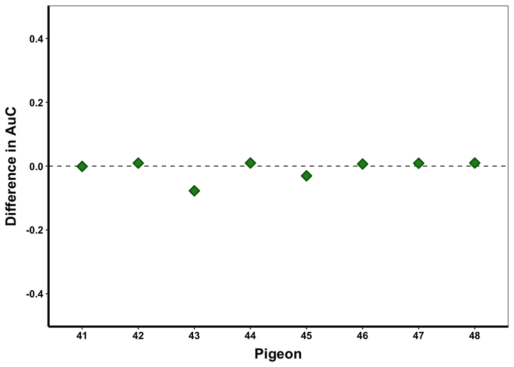

```r
# --- 5. Plot Difference in AuC (Replicates Figure 2) ---
filter(auc_data, Experiment == 1 & Subject != "Mean") |>
  mutate(Subject = str_remove(Subject, "P")) |>
  pivot_wider(names_from = Amount, values_from = AuC) |>
  # Calculate 16-pellet AuC minus 32-pellet AuC
  mutate(Diff_AuC = `16` - `32`) |>
  ggplot(aes(Subject, Diff_AuC)) +
  geom_hline(yintercept = 0, linetype = 2, color = "gray30") +
  geom_point(fill = "forestgreen", color = "darkgreen", size = 3, stroke = 1, shape = 23) +
  scale_y_continuous(limits = c(-.503, .503), breaks = seq(-1, 1, .2), expand = c(0,0)) +
  labs(x = "Pigeon", y = "Difference in AuC") +
  theme_bw() + mattheme
```

## Experiment 2: Two Probabilistic Rewards

In Experiment 2, the probabilities of both options were reduced by a common multiplier (1.0, 0.75, or 0.25), creating choices where both outcomes were probabilistic. The analysis fits a generalized hyperboloid model (Equation 2 from the paper) to the data from each condition.

```r
# --- 1. Define Bayesian Nonlinear Model (Exp 2) ---
# This is the generalized hyperboloid model (Equation 2):
# RSV = ((1 + b * OAs_Sm)^s) / ((1 + b * OAs)^s)
# We again use the logit-transformed version for beta regression.
exp2_model_formula <- bf(
  RSV ~ log((((1 + b * OAs_Sm)^s) / ((1 + b * OAs)^s)) / (1 - (((1 + b * OAs_Sm)^s) / ((1 + b * OAs)^s)))),
  b + s ~ 0 + Subject,
  phi ~ 0 + Subject,
  nl = TRUE
)

# --- 2. Create a Wrapper Function to Fit Models ---
# This function avoids repeating the brm call 6 times.
fit_brm_model_exp2 <- function(data_filter, file_name) {
  brm(
    formula = exp2_model_formula,
    data = data_filter,
    family = beta_family(),
    prior = model_priors, # Using the same priors as Exp 1
    iter = 4000, warmup = 2000, chains = 4, cores = 4, refresh = 0,
    backend = "cmdstanr",
    control = list(adapt_delta = 0.99, max_treedepth = 15), # Stricter controls
    file = file_name
  )
}

# --- 3. Fit All 6 Models for Experiment 2 ---
filtered_data_exp2 <- filter(combined_data, Experiment == 2 & Rep == 0)

# 16-Pellet Models
model_exp2_16p_m100 <- fit_brm_model_exp2(filter(filtered_data_exp2, Amount == 16, Multiplier == 1.00), "rds/bf_mod3a.rds")
model_exp2_16p_m75  <- fit_brm_model_exp2(filter(filtered_data_exp2, Amount == 16, Multiplier == 0.75), "rds/bf_mod3b.rds")
model_exp2_16p_m25  <- fit_brm_model_exp2(filter(filtered_data_exp2, Amount == 16, Multiplier == 0.25), "rds/bf_mod3c.rds")

# 32-Pellet Models
model_exp2_32p_m100 <- fit_brm_model_exp2(filter(filtered_data_exp2, Amount == 32, Multiplier == 1.00), "rds/bf_mod4a.rds")
model_exp2_32p_m75  <- fit_brm_model_exp2(filter(filtered_data_exp2, Amount == 32, Multiplier == 0.75), "rds/bf_mod4b.rds")
model_exp2_32p_m25  <- fit_brm_model_exp2(filter(filtered_data_exp2, Amount == 32, Multiplier == 0.25), "rds/bf_mod4c.rds")
```

The plots below replicate Figures 3, 4, and 5 from the paper, showing the discounting curves for each of the three multiplier conditions. The x-axis is “Relative Odds Against,” which is the odds against for the larger, less probable option.

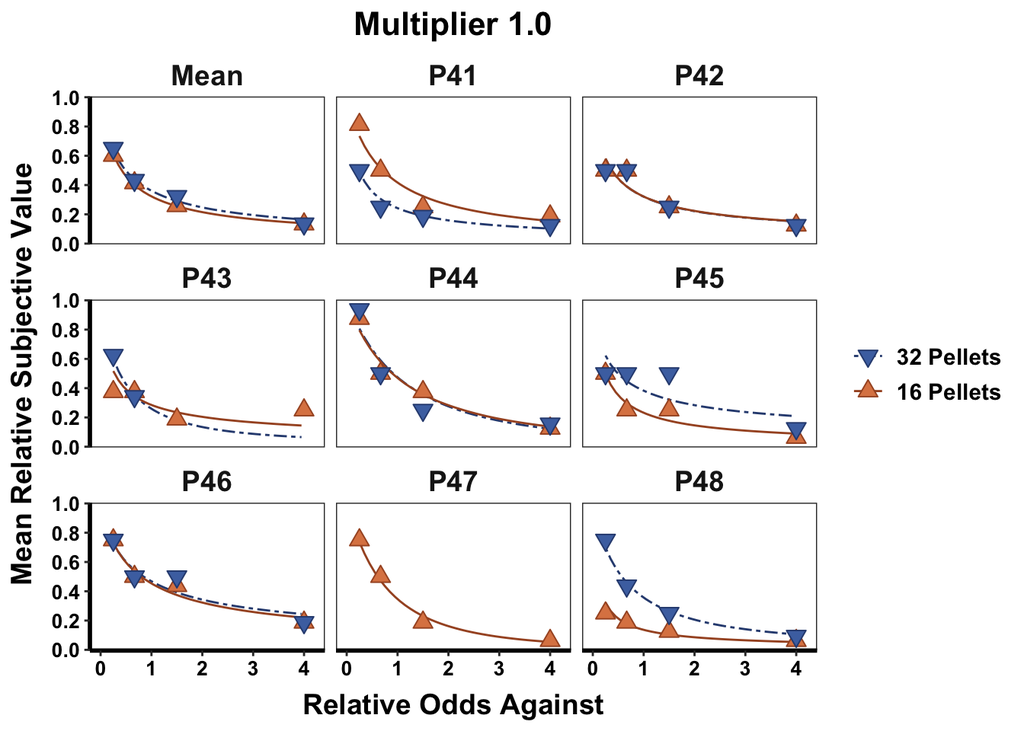

```r
# --- 1. Create a Wrapper Function for Predictions ---
generate_pred_curves_exp2 <- function(model, data_filter) {
  # Remove unused factor levels (like P47) from the filtered data
  data_filter <- droplevels(data_filter)

  # Create a prediction grid using only the levels present in the filtered data
  new_data <- tidyr::expand(
    data_filter,
    nesting(Subject), # Use nesting to ensure only valid subjects are used
    nesting(OAs_Sm),
    OAs = seq(min(OAs), max(OAs), .1)
  )

  # Generate and summarize posterior predictions
  add_epred_draws(model, newdata = new_data) |>
    group_by(Subject, OAs) |>
    summarize(.epred = median(.epred), .groups = 'drop') |>
    mutate(Amount = unique(data_filter$Amount), Multiplier = unique(data_filter$Multiplier))
}

# --- 2. Generate Predictions for all 6 Models ---
filtered_data_exp2 <- filter(combined_data, Experiment == 2 & Rep == 0)

pred_curves_exp2 <- bind_rows(
  generate_pred_curves_exp2(model_exp2_16p_m100, filter(filtered_data_exp2, Amount == 16, Multiplier == 1.00)),
  generate_pred_curves_exp2(model_exp2_16p_m75,  filter(filtered_data_exp2, Amount == 16, Multiplier == 0.75)),
  generate_pred_curves_exp2(model_exp2_16p_m25,  filter(filtered_data_exp2, Amount == 16, Multiplier == 0.25)),
  generate_pred_curves_exp2(model_exp2_32p_m100, filter(filtered_data_exp2, Amount == 32, Multiplier == 1.00)),
  generate_pred_curves_exp2(model_exp2_32p_m75,  filter(filtered_data_exp2, Amount == 32, Multiplier == 0.75)),
  generate_pred_curves_exp2(model_exp2_32p_m25,  filter(filtered_data_exp2, Amount == 32, Multiplier == 0.25))
) |>
  mutate(
    # Calculate the "Relative Odds Against" for the x-axis
    # This corresponds to the odds against in the 1.0 Multiplier condition
    Prob_Lg = 1 / (OAs + 1),
    Rel_Prob = Prob_Lg / Multiplier,
    Rel_OAs = (1 - Rel_Prob) / Rel_Prob,
    # Create labels for faceting
    Multiplier_Label = factor(Multiplier, levels = c("1","0.75","0.25"),
                              labels = c("Multiplier 1.0","Multiplier 0.75","Multiplier 0.25")),
    Amount = factor(Amount, levels = c(32, 16), labels = c("32 Pellets", "16 Pellets"))
  )

# --- 3. Prep Plotting Data ---
plot_data_exp2 <- filter(plot_data_mean, Experiment == 2) |>
  mutate(
    # Calculate "Relative Odds Against" for the observed data points
    Rel_Prob = Prob_Lg / Multiplier,
    Rel_OAs = (1 - Rel_Prob) / Rel_Prob,
    Multiplier_Label = factor(Multiplier, levels = c("1","0.75","0.25"),
                              labels = c("Multiplier 1.0","Multiplier 0.75","Multiplier 0.25"))
  )

# --- 4. Create Faceted Plotting Function ---
plot_exp2_by_multiplier <- function(mult_label) {
  ggplot(filter(plot_data_exp2, Rep == 0, Multiplier_Label == mult_label),
         aes(Rel_OAs, RSV, shape = Amount, group = Amount, linetype = Amount, fill = Amount, color = Amount)) +
    # Plot the smooth model-fit curves
    geom_line(data = filter(pred_curves_exp2, Multiplier_Label == mult_label),
              aes(x = Rel_OAs, y = .epred)) +
    # Plot the replication data (open symbols)
    geom_point(data = filter(plot_data_exp2, Rep == 1, Multiplier_Label == mult_label),
               size = 5, fill = NA, show.legend = FALSE) +
    # Plot the original data (filled symbols)
    geom_point(size = 3) +
    scale_y_continuous(limits = c(-.005, 1.005), breaks = seq(0,1,by=0.2), expand = c(0,0)) +
    scale_x_continuous(limits = c(0, 4.2), breaks= seq(0,4,by=1)) +
    scale_shape_manual(name = NULL, values = c("32 Pellets"=25, "16 Pellets"=24)) +
    scale_linetype_manual(name = NULL, values = c("32 Pellets"="twodash", "16 Pellets"="solid")) +
    scale_fill_manual(name = NULL, values = c("32 Pellets"="#4C72B0", "16 Pellets"="#DD8452")) +
    scale_color_manual(name = NULL, values = c("32 Pellets"="#2E4A7F", "16 Pellets"="#A65329")) +
    labs(x="Relative Odds Against", y="Mean Relative Subjective Value", title = mult_label) +
    facet_wrap(~Subject, ncol = 3) +
    theme_bw() + mattheme
}

# --- 5. Generate Plots (Replicates Figures 3, 4, 5) ---
print(plot_exp2_by_multiplier("Multiplier 1.0"))
```

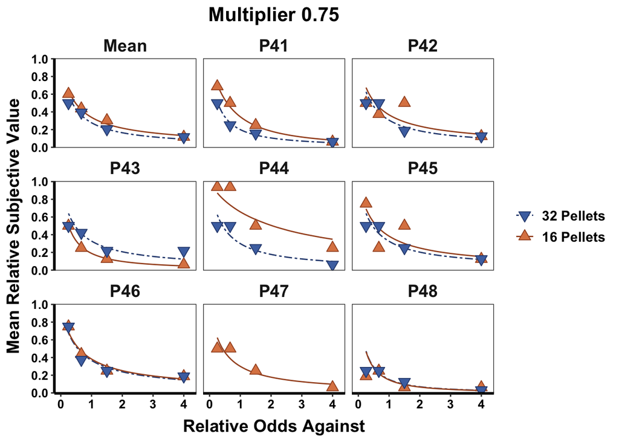

```r
print(plot_exp2_by_multiplier("Multiplier 0.75"))
```

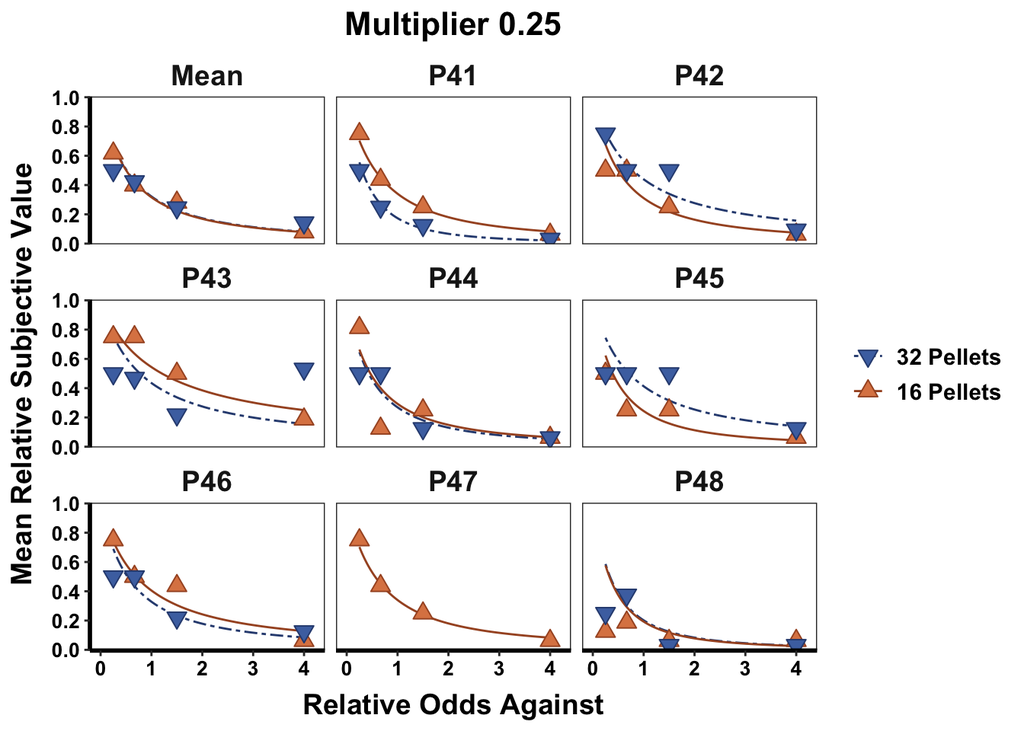

```r
print(plot_exp2_by_multiplier("Multiplier 0.25"))
```

The table below replicates the key findings from Table 2 in the paper, showing AuC, $R^2$, and parameter estimates for Experiment 2, broken down by multiplier condition.

```r
# --- 1. Calculate Bayesian R-squared ---
filtered_data_exp2 <- filter(combined_data, Experiment == 2 & Rep == 0)
r2_data_exp2 <- bind_rows(
  cbind(filter(filtered_data_exp2, Amount == 16, Multiplier == 1.00), as.data.frame(t(posterior_epred(model_exp2_16p_m100)))),
  cbind(filter(filtered_data_exp2, Amount == 32, Multiplier == 1.00), as.data.frame(t(posterior_epred(model_exp2_32p_m100)))),
  cbind(filter(filtered_data_exp2, Amount == 16, Multiplier == 0.75), as.data.frame(t(posterior_epred(model_exp2_16p_m75)))),
  cbind(filter(filtered_data_exp2, Amount == 32, Multiplier == 0.75), as.data.frame(t(posterior_epred(model_exp2_32p_m75)))),
  cbind(filter(filtered_data_exp2, Amount == 16, Multiplier == 0.25), as.data.frame(t(posterior_epred(model_exp2_16p_m25)))),
  cbind(filter(filtered_data_exp2, Amount == 32, Multiplier == 0.25), as.data.frame(t(posterior_epred(model_exp2_32p_m25))))
) |>
  pivot_longer(cols = starts_with("V"), names_to = "Sim", values_to = ".epred") |>
  group_by(Multiplier, Subject, Amount, OAs, RSV) |>
  summarize(.epred = median(.epred), .groups = 'drop') |>
  mutate(residual = RSV - .epred) |>
  group_by(Multiplier, Subject, Amount) |>
  mutate(residual2 = residual^2, tot = (RSV - mean(RSV))^2) |>
  summarise(ss_res = sum(residual2), ss_tot = sum(tot), .groups = 'drop') |>
  mutate(R2 = 1 - (ss_res / ss_tot), R2 = ifelse(R2 < 0, NA, R2)) |> # Set negative R2 to NA
  select(-ss_res, -ss_tot)

# --- 2. Extract Parameter Estimates ---
params_data_exp2 <- bind_rows(
  gather_draws(model_exp2_16p_m100, `b_.*`, regex=TRUE)[,-c(1:3)] |> mutate(Amount = 16, Multiplier = 1.00),
  gather_draws(model_exp2_16p_m75,  `b_.*`, regex=TRUE)[,-c(1:3)] |> mutate(Amount = 16, Multiplier = 0.75),
  gather_draws(model_exp2_16p_m25,  `b_.*`, regex=TRUE)[,-c(1:3)] |> mutate(Amount = 16, Multiplier = 0.25),
  gather_draws(model_exp2_32p_m100, `b_.*`, regex=TRUE)[,-c(1:3)] |> mutate(Amount = 32, Multiplier = 1.00),
  gather_draws(model_exp2_32p_m75,  `b_.*`, regex=TRUE)[,-c(1:3)] |> mutate(Amount = 32, Multiplier = 0.75),
  gather_draws(model_exp2_32p_m25,  `b_.*`, regex=TRUE)[,-c(1:3)] |> mutate(Amount = 32, Multiplier = 0.25)
) |>
  separate(col = .variable, into = c("Parameter", "Subject"), sep = "_Subject") |>
  mutate(Parameter = str_remove(Parameter, "b_")) |>
  filter(Parameter != "phi") |>
  group_by(Multiplier, Subject, Amount, Parameter) |>
  mutate(pd = ecdf(.value)(1), pd = ifelse(pd >= .5, pd, 1 - pd)) |>
  group_by(Parameter, Multiplier, Subject, Amount, pd) |>
  summarise(se = sd(.value), .value = median(.value), .groups = 'drop') |>
  mutate(pd = ifelse(Parameter == "b" & .value < 1 & pd > .5, 1 - pd,
                     ifelse(Parameter == "s" & .value > 1 & pd > .5, 1 - pd, pd))) |>
  mutate(across(c(.value, se, pd), ~sprintf("%.3f", round(.,3)))) |>
  ungroup() |> mutate(se = paste0("(", se, ")")) |>
  rename("Estimate" = ".value", "SE" = "se") |>
  unite("Estimate (SE)", "Estimate", "SE", sep = " ") |>
  relocate(Parameter, Multiplier, Subject, Amount, 'Estimate (SE)') |>
  pivot_wider(names_from = Parameter, values_from = c(`Estimate (SE)`, pd))

# --- 3. Create Full Results Table (Replicates Table 2) ---
results_table_exp2 <- full_join(filter(auc_data, Experiment == 2), r2_data_exp2, by = c("Subject", "Amount", "Multiplier")) |>
  full_join(params_data_exp2, by = c("Subject", "Multiplier", "Amount")) |>
  mutate(Subject = factor(Subject, levels = c("P41","P42","P43","P44","P45","P46","P47","P48","Mean"))) |>
  # Order by multiplier, then subject, then amount
  arrange(desc(Multiplier), Subject, Amount) |>
  select(Multiplier, Subject, Amount, AuC, R2, `Estimate (SE)_b`, pd_b, `Estimate (SE)_s`, pd_s) |>
  mutate(across(where(is.character), ~replace_na(., ""))) # Replace NA with blank string for table

print(as.data.frame(results_table_exp2))
```

```
   Multiplier Subject Amount        AuC        R2 Estimate (SE)_b  pd_b
1        1.00     P41     16 0.28320312 0.9472253   1.531 (2.727) 0.709
2        1.00     P41     32 0.18229167 0.9561129   8.125 (5.419) 0.994
3        1.00     P42     16 0.24739583 0.8148225   6.637 (5.178) 0.969
4        1.00     P42     32 0.24739583 0.8192138   6.679 (5.233) 0.971
5        1.00     P43     16 0.23437500        NA  10.865 (6.740) 0.983
6        1.00     P43     32 0.30273438 0.9846794   2.023 (4.893) 0.653
7        1.00     P44     16 0.31901042 0.9548914   0.580 (2.830) 0.332
8        1.00     P44     32 0.27994792 0.8978560   0.387 (1.088) 0.175
9        1.00     P45     16 0.18880208 0.9145897   6.430 (4.503) 0.984
10       1.00     P45     32 0.35156250 0.4648477   7.759 (5.626) 0.976
11       1.00     P46     16 0.35807292 0.9578501   2.670 (3.369) 0.904
12       1.00     P46     32 0.38411458 0.8906182   3.401 (4.237) 0.858
13       1.00     P47     16 0.21484375 0.9899320   0.461 (1.481) 0.149
14       1.00     P48     16 0.11393229 0.6934508  15.819 (7.141) 0.999
```

[output cut: 89 more lines]

```r
# --- 4. Test for Amount Effect on AuC (by Multiplier) ---
# As in Exp 1, we test for an amount effect, but now separately
# for each multiplier condition.
cat("\n--- Experiment 2: Amount Effect on AuC by Multiplier ---\n")
```

```
--- Experiment 2: Amount Effect on AuC by Multiplier ---
```

```r
auc_data_exp2 <- filter(auc_data, Experiment == 2 & Subject != "Mean")
# Loop through each multiplier
for (m in c(1.0, 0.75, 0.25)) {
  cat(paste("\nMultiplier:", m, "\n"))
  mod <- glmmTMB(
    AuC ~ as.factor(Amount) + (1 | Subject),
    family = beta_family(),
    data = filter(auc_data_exp2, Multiplier == m)
  )
  # No significant effect of amount was found in any condition
  print(summary(mod))
}
```

```
Multiplier: 1
 Family: beta  ( logit )
Formula:          AuC ~ as.factor(Amount) + (1 | Subject)
Data: filter(auc_data_exp2, Multiplier == m)

      AIC       BIC    logLik -2*log(L)  df.resid
    -30.0     -27.1      19.0     -38.0        11

Random effects:

Conditional model:
 Groups  Name        Variance Std.Dev.
 Subject (Intercept) 0.02732  0.1653
Number of obs: 15, groups:  Subject, 8

Dispersion parameter for beta family (): 49.1

Conditional model:
                    Estimate Std. Error z value Pr(>|z|)
(Intercept)          -1.1394     0.1304  -8.736   <2e-16 ***
as.factor(Amount)32   0.2091     0.1674   1.249    0.211
---
Signif. codes:  0 '***' 0.001 '**' 0.01 '*' 0.05 '.' 0.1 ' ' 1

Multiplier: 0.75
 Family: beta  ( logit )
Formula:          AuC ~ as.factor(Amount) + (1 | Subject)
Data: filter(auc_data_exp2, Multiplier == m)

      AIC       BIC    logLik -2*log(L)  df.resid
    -25.5     -22.7      16.8     -33.5        11

Random effects:

Conditional model:
 Groups  Name        Variance Std.Dev.
 Subject (Intercept) 0.09175  0.3029
Number of obs: 15, groups:  Subject, 8

Dispersion parameter for beta family (): 38.4
```

[output cut: 16 more lines]

```
Random effects:

Conditional model:
 Groups  Name        Variance Std.Dev.
 Subject (Intercept) 0.1523   0.3903
Number of obs: 15, groups:  Subject, 8

Dispersion parameter for beta family (): 49.9

Conditional model:
                    Estimate Std. Error z value Pr(>|z|)
(Intercept)         -1.43669    0.18829  -7.630 2.34e-14 ***
as.factor(Amount)32  0.02984    0.18535   0.161    0.872
---
Signif. codes:  0 '***' 0.001 '**' 0.01 '*' 0.05 '.' 0.1 ' ' 1
```